## NDVI time series analysis

### Objectives

This manual will help you construct a time series using MODIS data. At the end of this session, you will be able to:

1. Import NDVI data into R software
2. Insert a temporal ID into the data
3. Create a time series
4. Plot and export graphs

For more details on source of MODIS data see http://pekko.geog.umd.edu/usda/beta/data_new.php. Otherwise, download the sample dataset we will use in this session from this link https://drive.google.com/open?id=0B_Gkb_0tNKkQUVc5NUhKRzlhZTg

Before you start this session, it is important you have (i) the latest [R software] (https://cran.r-project.org/bin/windows/base/) and (ii) [Rstudio](https://www.rstudio.com/) installed in your computer.

You can now start the session but first clear your work space:

```r
rm(list = ls(all = TRUE))
```

### Preliminaries

You need to first install all the required packages. Type (within R) install packages(“name of package”) (This needs to be done just once.). You then load the packages using the ‘library’ function:

```r
library(raster) #working with rasters
library(rgdal) #working with geospatial data
```

```r
library(ggplot2) #creating graphs
library(dplyr) #subsetting by season
library(lubridate) #working with dates
library(grid) #arranging plots
library(gridExtra) #arranging plots
```

Set your working directory as follows:

```r
setwd("C:/Users/jymutua/Documents/LDN_Workshop/Sample_dataset/NDVI_data")
```

This needs to be done every time you start R. (There is a way to have the package loaded automatically every time, but we won’t discuss that here). To get help on the functions and data sets in R, use `help()` or `?`. For example, to view the help file for the `calc` function, type one of the following:

```r
help(calc)
?calc
```

Import all NDVI raster datasets in your working directory and create a raster stack

```r
NDVI_Otji_stack <- stack(list.files(getwd(), full.names = TRUE, pattern = ".tif$"))
```

Insert a Temporal id to the data frame. Characters corresponding to the year are located between the 20 and 23 position, while characters corresponding to the date are located between the 24 and 26 position

```r
oldnames<-names(NDVI_Otji_stack)
head(oldnames)
```

```
## [1] "Otjozondjupa_NDVI_.2005001.C05.NDVI.MOD44.D16.R000250.MODAPS.v2_wm2"
## [2] "Otjozondjupa_NDVI_.2005017.C05.NDVI.MOD44.D16.R000250.MODAPS.v2_wm2"
## [3] "Otjozondjupa_NDVI_.2005033.C05.NDVI.MOD44.D16.R000250.MODAPS.v2_wm2"
## [4] "Otjozondjupa_NDVI_.2005049.C05.NDVI.MOD44.D16.R000250.MODAPS.v2_wm2"
## [5] "Otjozondjupa_NDVI_.2005065.C05.NDVI.MOD44.D16.R000250.MODAPS.v2_wm2"
## [6] "Otjozondjupa_NDVI_.2005081.C05.NDVI.MOD44.D16.R000250.MODAPS.v2_wm2"
```

```r
year<-substr(oldnames,20,23)
table(year)
```

```
## year
## 2005 2006 2007 2008 2009 2010 2011 2012 2013 2014 2015
##   23   23   23   22   23   23   23   23   23   23   23
```

```r
julianDay<-substr(oldnames,24,26)
```

Calculate mean NDVI for each raster and convert output array to a data frame

```r
avg_NDVI_Otji <- as.data.frame(cellStats(NDVI_Otji_stack,mean))
```

Rename the NDVI column

```r
names(avg_NDVI_Otji) <- "meanNDVI"
```

Add julianDay values as a column in the data frame

```r
avg_NDVI_Otji$julianDay <- julianDay
```

Check out the class in the new column

```r
class(avg_NDVI_Otji$julianDay)
```

```
## [1] "character"
```

Create a time vector and convert it to a date

```r
tVector<-paste(year,julianDay,sep="-")
timeNDVI<-as.Date(tVector,format = "%Y-%j")
```

Add date values as a column in the data frame

```r
avg_NDVI_Otji$date <- timeNDVI
```

Check out classes of the two columns now

```r
class(avg_NDVI_Otji$date)
```

```
## [1] "Date"
```

```r
class(avg_NDVI_Otji$julianDay)
```

```
## [1] "character"
```

Add site and year columns to the data frame

```r
avg_NDVI_Otji$site <- "Otjiwarongo Region"
avg_NDVI_Otji$year <- year
```

### Plot time series

Plot NDVI by year although this doesn’t make sense

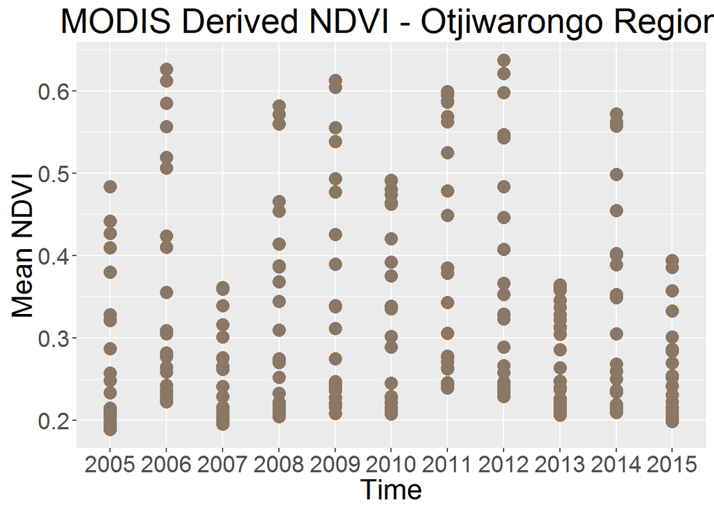

```r
ggplot(avg_NDVI_Otji, aes(year, meanNDVI), na.rm=TRUE) +
  geom_point(size=4,colour = "PeachPuff4") +
  ggtitle("MODIS Derived NDVI - Otjiwarongo Region") +
  xlab("Time") + ylab("Mean NDVI") +
  theme(text = element_text(size=20))
```

Write NDVI data to a comma separated file in your local drive

```r
Otji_NDVI_Values<-avg_NDVI_Otji
```

Drop the *row.names* column

```r
row.names(Otji_NDVI_Values)<-NULL
write.csv(Otji_NDVI_Values, file="meanNDVI_Otji_2005-2015.csv")
```

Add month to data frame

```r
avg_NDVI_Otji$month  <- month(avg_NDVI_Otji$date)
```

Subset data by season by creating a new categorical variable called season by grouping months together

```r
avg_NDVI_Otji_Seasons <- avg_NDVI_Otji %>%
  mutate(season =
           ifelse(month %in% c(12, 1, 2, 3, 4, 5), "Hot-Wet",
                  ifelse(month %in% c(6, 7, 8), "Cool-Dry",
                         ifelse(month %in% c(9, 10, 11), "Hot-Dry", "Error"))))
```

Let’s check to see if that worked

```r
head(avg_NDVI_Otji_Seasons$month)
```

```
## [1] 1 1 2 2 3 3
```

```r
head(avg_NDVI_Otji_Seasons$season)
```

```
## [1] "Hot-Wet" "Hot-Wet" "Hot-Wet" "Hot-Wet" "Hot-Wet" "Hot-Wet"
```

```r
tail(avg_NDVI_Otji_Seasons$month)
```

```
## [1]  9 10 11 11 12 12
```

```r
tail(avg_NDVI_Otji_Seasons$season)
```

```
## [1] "Hot-Dry" "Hot-Dry" "Hot-Dry" "Hot-Dry" "Hot-Wet" "Hot-Wet"
```

### Start of monthly plots

Aggregate data by month

```r
monthNDVI<-avg_NDVI_Otji_Seasons %>%
  group_by(month) %>%
  summarise(monthNDVI=mean(meanNDVI, na.rm=TRUE))
```

Convert month numeric to month abbreviation

```r
monthNDVI$month_name <- month.abb[monthNDVI$month]
```

Reassign the “month_name”" field to a factor

```r
monthNDVI$month_name = factor(monthNDVI$month_name,
                              levels=c('Jan','Feb','Mar',
                                       'Apr','May','Jun','Jul',
                                       'Aug','Sep','Oct',
                                       'Nov','Dec'))
```

Plot data by month

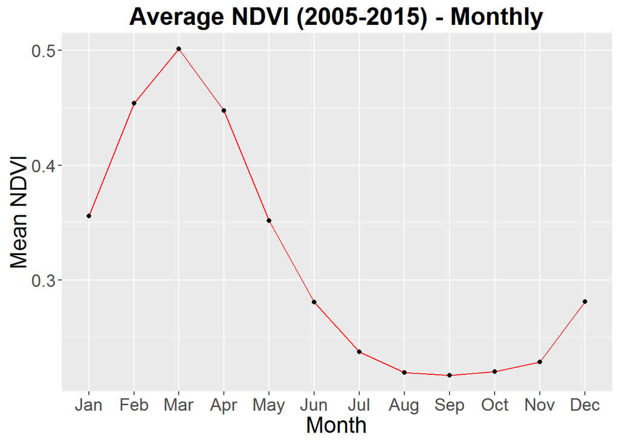

```r
Monthly_NDVI_Plot<-ggplot(monthNDVI, aes(month_name, monthNDVI, group=4)) +
  geom_line(colour="red") +
  ggtitle("Average NDVI (2005-2015) - Monthly") +
  xlab("Month") + ylab("Mean NDVI") +
  theme(plot.title = element_text(lineheight=.8, face="bold",
                                  size = 20)) +
  theme(text = element_text(size=18)) + geom_point()
Monthly_NDVI_Plot
```

```r
ggsave(file="Otjiwarongo_Monthly_NDVI.pdf", width = 297, height = 210, units = "mm")
```

### Start of indivindual seasonal plots

Plot HOT-WET Season

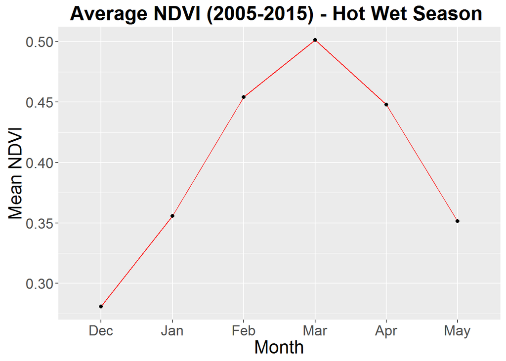

```r
Hot_Wet <- subset(monthNDVI, month >= 12 | month <= 5)
target <- c("12", "5", "4", "3", "2", "1")
Hot_Wet<-Hot_Wet[match(target, Hot_Wet$month),]
Hot_Wet$month_name <- factor(Hot_Wet$month_name, c("Dec", "Jan", "Feb", "Mar", "Apr", "May"))
Hot_Wet_NDVI_Plot<-ggplot(Hot_Wet, aes(month_name, monthNDVI, group=1)) +
  geom_line(colour="red") +
  ggtitle("Average NDVI (2005-2015) - Hot Wet Season ") +
  xlab("Month") + ylab("Mean NDVI") +
  theme(plot.title = element_text(lineheight=.8, face="bold",
                                  size = 20)) +
  theme(text = element_text(size=18)) + geom_point()
Hot_Wet_NDVI_Plot
```

```r
ggsave(file="Otjiwarongo_Hot_Wet_NDVI.pdf", width = 297, height = 210, units = "mm")
```

Plot COOL-DRY Season

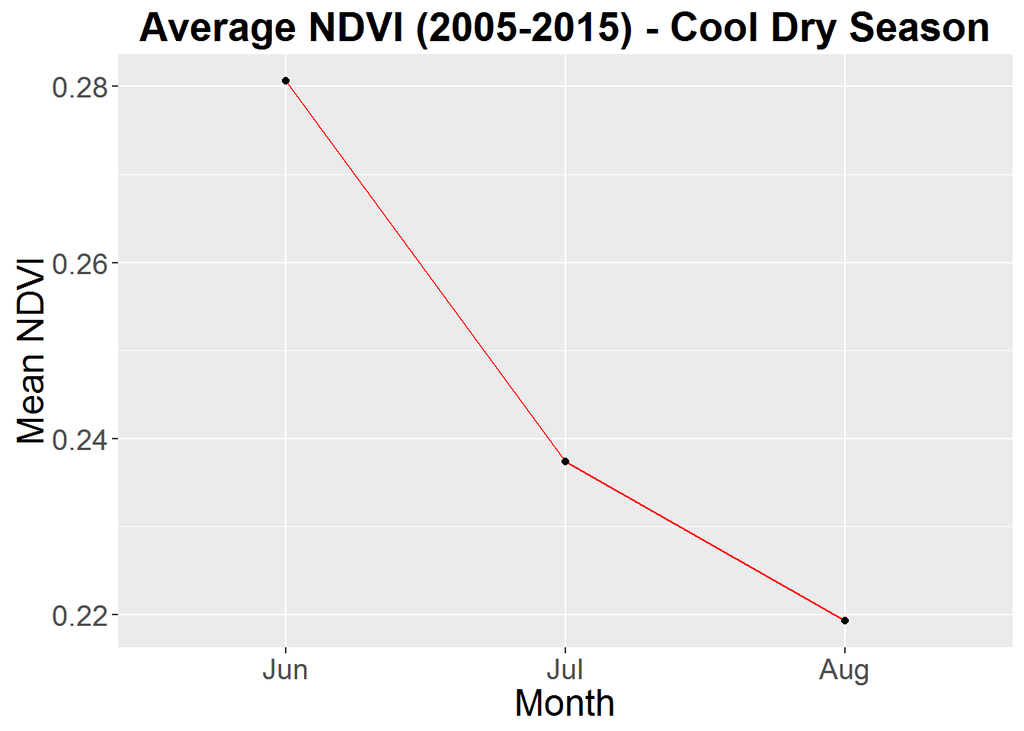

```r
Cool_Dry <- subset(monthNDVI, month <= 8 & month >= 6)
Cool_Dry_NDVI_Plot<-ggplot(Cool_Dry, aes(month_name, monthNDVI, group=1)) +
  geom_line(colour="red") +
  ggtitle("Average NDVI (2005-2015) - Cool Dry Season") +
  xlab("Month") + ylab("Mean NDVI") +
  theme(plot.title = element_text(lineheight=.8, face="bold",
                                  size = 20)) +
  theme(text = element_text(size=18)) + geom_point()
Cool_Dry_NDVI_Plot
```

```r
ggsave(file="Otjiwarongo_Cool_Dry_NDVI.pdf", width = 297, height = 210, units = "mm")
```

Plot HOT DRY Season

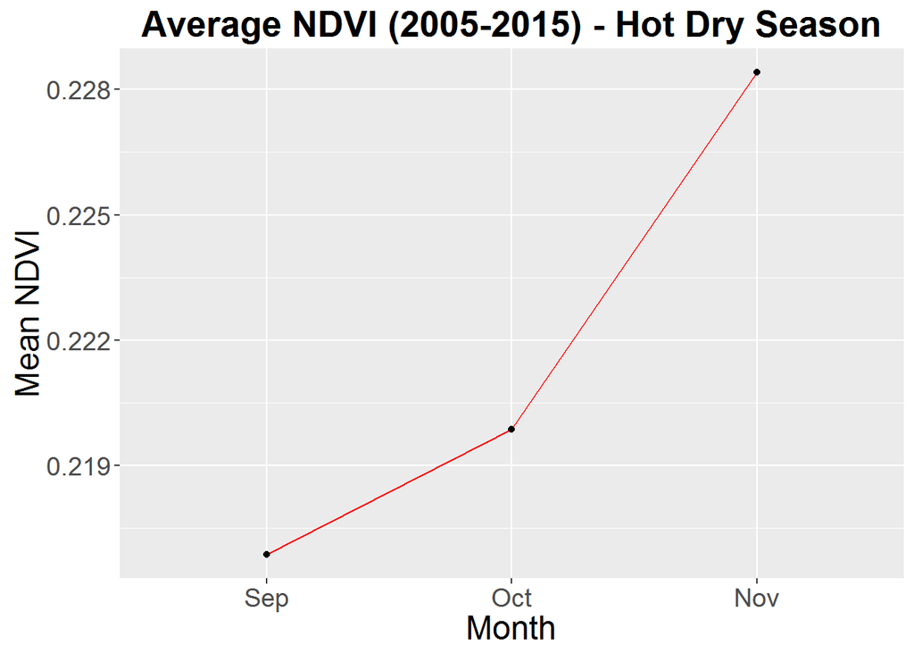

```r
Hot_Dry <- subset(monthNDVI, month <= 11 & month >= 9)
Hot_Dry_NDVI_Plot<-ggplot(Hot_Dry, aes(month_name, monthNDVI, group=1)) +
  geom_line(colour="red") +
  ggtitle("Average NDVI (2005-2015) - Hot Dry Season") +
  xlab("Month") + ylab("Mean NDVI") +
  theme(plot.title = element_text(lineheight=.8, face="bold",
                                  size = 20)) +
  theme(text = element_text(size=18)) + geom_point()
Hot_Dry_NDVI_Plot
```

```r
ggsave(file="Otjiwarongo_Hot_Dry_NDVI.pdf", width = 297, height = 210, units = "mm")
```

### Start of merged seasonal plots

Let’s aggregate data by season

```r
seasonNDVI<-avg_NDVI_Otji_Seasons %>%
  group_by(year, season) %>%
  summarise(seasonNDVI=mean(meanNDVI, na.rm=TRUE))
```

Export comma separated file of seasonal NDVI values

```r
write.csv(seasonNDVI, file="Seasonal_NDVI_2005-2015.csv")
```

Plot data by season

```r
Seasonal_NDVI_Plot<-ggplot(seasonNDVI, aes(year, seasonNDVI, group=3)) +
  geom_line(colour="red") +
  ggtitle("Average NDVI (2005-2015) - Seasonal") +
  xlab("Year") + ylab("Mean NDVI") +
  theme(plot.title = element_text(lineheight=.8, face="bold",
                                  size = 20)) +
  theme(text = element_text(size=18)) + geom_point()
```

Plot the same plot as before but with one plot per season, save as .pdf

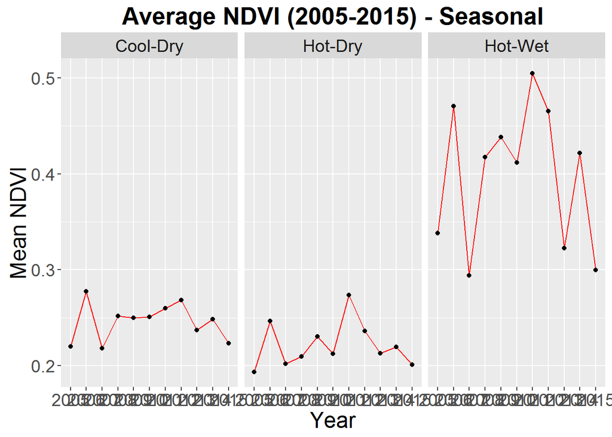

```r
Seasonal_NDVI_Plot + facet_grid(. ~ season)
```

```r
ggsave(file="Otjiwarongo_Seasonal_NDVI.pdf", width = 297, height = 210, units = "mm")
```

Plot the same plot in a landscape orientation, save as .pdf

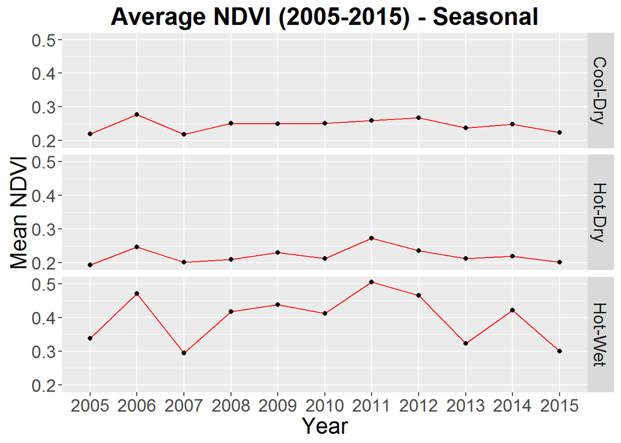

```r
Seasonal_NDVI_Plot + facet_grid(season ~ .)
```

```r
ggsave(file="Otjiwarongo_Seasonal_NDVI.pdf", width = 297, height = 210, units = "mm")
```